# H06 daily-metric analysis preparation and provenance

From participant-day light-exposure metrics and recorded contexts to complementary association estimates

Last modified:

August 13, 2026

This page explains how the complementary H06 participant-day analysis was prepared, fitted, checked, and translated into the reported tables and figures. The selected hourly H06 analysis remains the main H06 result. A participant-day is one eligible local calendar day from one participant. Each admissible light-exposure metric contributes at most one row for that participant-day, so days are not weighted by their number of supported hours.

The complementary H06 daily-metric results report contains the association estimates, confidence intervals, multiplicity decisions, site-specific patterns, complementary analyses, and the comparison with the selected main hourly H06 analysis.

**NoteExecution boundary**

This page verifies stored file identities and schemas and calculates only bounded descriptive summaries of the already fitted samples. Model estimates, predictions, residual correlation, p-values, false-discovery-rate (FDR) adjustments, deletion analyses, and nonlinear clock-time functions are read from stored outputs. FDR adjustment limits the expected proportion of false discoveries within each defined family. Rendering this page does not fit or refit a model, regenerate a prediction, rerun a sensitivity analysis, resample, or simulate.

## Analysis path

The primary path estimates each context separately for each daily metric. The predictor-by-site interaction path allows that association to differ among sites. Two exploratory paths then examine covariate stability and 30-minute clock-time profiles without changing the primary participant-day estimand. The nonlinear generalized additive mixed model (GAMM) analysis represents smooth clock-time variation while accounting for repeated measurements. Its working first-order autoregressive correlation, AR(1), allows adjacent residuals within a participant-day sequence to be correlated. A pointwise 95% confidence interval (95% CI) assesses one displayed estimate and is not a simultaneous band. Model checks assess fit, observed support, residual behavior, and sensitivity evidence.

**Show the R code used for this display**

```
flowchart TD
  A["Verified participant-day light-exposure metrics"] --> D["Metric-specific participant-day frames"]
  B["Work day or Free day and daily activity status"] --> D
  C["Previous-night sleep duration"] --> D
  D --> E["Fixed-site common-association model"]
  D --> F["Predictor-by-site interaction model"]
  D --> G["Exploratory jointly adjusted model"]
  H["Supported 30-minute arithmetic-mean melEDI"] --> I["Exploratory clock-time GAMM with working AR(1)"]
  E --> J["Contrasts, pointwise 95% CIs, FDR families, and model checks"]
  F --> J
  G --> K["Separate exploratory FDR families and stability checks"]
  I --> L["Pointwise clock-time functions and whole-function tests"]
  J --> M["Complementary H06 daily-metric results"]
  K --> M
  L --> M
```

```
flowchart TD
  A["Verified participant-day light-exposure metrics"] --> D["Metric-specific participant-day frames"]
  B["Work day or Free day and daily activity status"] --> D
  C["Previous-night sleep duration"] --> D
  D --> E["Fixed-site common-association model"]
  D --> F["Predictor-by-site interaction model"]
  D --> G["Exploratory jointly adjusted model"]
  H["Supported 30-minute arithmetic-mean melEDI"] --> I["Exploratory clock-time GAMM with working AR(1)"]
  E --> J["Contrasts, pointwise 95% CIs, FDR families, and model checks"]
  F --> J
  G --> K["Separate exploratory FDR families and stability checks"]
  I --> L["Pointwise clock-time functions and whole-function tests"]
  J --> M["Complementary H06 daily-metric results"]
  K --> M
  L --> M
```

**Show the R code used for this display**

```r
tibble::tribble(
  ~Activity, ~Status, ~Purpose,
  "Verify stored identities and schemas", "Executed", "Detects stale or mismatched inputs",
  "Summarize exact fitted rows", "Executed", "Makes metric-specific denominators visible",
  "Summarize category and site support", "Executed", "Shows the support behind fitted contrasts",
  "Fit or compare statistical models", "Not executed", "Stored fitted objects and results remain the source",
  "Generate predictions or contrasts", "Not executed", "Stored reader source data remain the source",
  "Calculate raw or adjusted p-values", "Not executed", "Stored complete-family results remain the source",
  "Rerun AR(1), deletion, resampling, or simulation", "Not executed", "Stored model-check sidecars remain the source"
) |>
  compact_gt()
```

Table 1: What this page reads and what it deliberately does not execute

| Activity | Status | Purpose |
| --- | --- | --- |
| Verify stored identities and schemas | Executed | Detects stale or mismatched inputs |
| Summarize exact fitted rows | Executed | Makes metric-specific denominators visible |
| Summarize category and site support | Executed | Shows the support behind fitted contrasts |
| Fit or compare statistical models | Not executed | Stored fitted objects and results remain the source |
| Generate predictions or contrasts | Not executed | Stored reader source data remain the source |
| Calculate raw or adjusted p-values | Not executed | Stored complete-family results remain the source |
| Rerun AR(1), deletion, resampling, or simulation | Not executed | Stored model-check sidecars remain the source |

## Exact inputs and analytical unit

### Verified provenance

The analysis consumed the current prepared metric and context artifacts. It did not rebuild measurement preparation or alter a metric locally, except for the documented task-local conversion of five gap-comparison clock outcomes from minutes to hours. That conversion was limited to H06 daily-metric sensitivity frames and left the primary, chest, paired, MDER, L10, temporal, and other hypothesis artifacts unchanged.

**Show the R code used for this display**

```r
input_provenance |>
  transmute(
    Input = case_when(
      grepl("results source", .data$input_role, ignore.case = TRUE) ~ "Daily-metric results source",
      grepl("results HTML", .data$input_role, ignore.case = TRUE) ~ "Daily-metric results HTML",
      grepl("source-data manifest", .data$input_role, ignore.case = TRUE) ~ "Reader source-data manifest",
      grepl("output manifest", .data$input_role, ignore.case = TRUE) ~ gsub(" output manifest", " outputs", .data$input_role),
      grepl("render QA", .data$input_role, ignore.case = TRUE) ~ "Reader render verification",
      grepl("figure QA", .data$input_role, ignore.case = TRUE) ~ "Reader figure verification",
      grepl("focused test", .data$input_role, ignore.case = TRUE) ~ "Reader structural verification",
      grepl("transition", .data$input_role, ignore.case = TRUE) ~ "Scientific transition record",
      grepl("revision record", .data$input_role, ignore.case = TRUE) ~ "Reader revision record",
      TRUE ~ .data$input_role
    ),
    Path = paste0("`", .data$relative_path, "`"),
    `SHA-256 prefix` = substr(.data$observed_sha256, 1L, 12L),
    Status = .data$verification_status
  ) |>
  gt::gt() |>
  gt::fmt_markdown(columns = "Path") |>
  compact_gt(font_size = 10.5)
```

Table 2: Verified scientific and reporting input identities

| Input | Path | SHA-256 prefix | Status |
| --- | --- | --- | --- |
| Scientific transition record | `audit/hypotheses/H06_daily/H06_daily_stage3_acceptance_stage4_transition.md` | 80d52eea0d17 | PASS |
| Scientific transition record | `audit/decisions/h06_daily_stage2_acceptance_stage3_transition.md` | 26e3cf5302db | PASS |
| Reader revision record | `audit/hypotheses/H06_daily/H06_daily_stage3_revision_gate.md` | 733dd1dd4c57 | PASS |
| Daily-metric results source | `notebooks/hypotheses/H06_daily.qmd` | 0318fd6cf874 | PASS |
| Daily-metric results HTML | `notebooks/hypotheses/H06_daily.html` | 5a20c0680011 | PASS |
| Reader source-data manifest | `artifacts/12_manifests/H06_daily/H06_daily_stage3_source_data_manifest.csv` | 77cd39b759a0 | PASS |
| Accepted Stage 3 outputs | `artifacts/12_manifests/H06_daily/H06_daily_stage3_output_manifest.csv` | 7c7658fca616 | PASS |
| Reader render verification | `artifacts/12_manifests/H06_daily/H06_daily_stage3_render_qa.csv` | d61a25505453 | PASS |
| Reader figure verification | `artifacts/12_manifests/H06_daily/H06_daily_stage3_revision_figure_readability_qa.csv` | 75f3e82a7fcf | PASS |
| Reader structural verification | `tests/hypotheses/H06_daily/test_h06_daily_stage3_reader_report.R` | 16e3d02bbfe4 | PASS |
| Non-L10 production outputs | `artifacts/12_manifests/H06_daily/H06_daily_non_l10_production_output_manifest.csv` | 63c6e873c35b | PASS |
| Gap clock repair outputs | `artifacts/12_manifests/H06_daily/H06_daily_gap_clock_repair_output_manifest.csv` | 54b63ff4dc3e | PASS |
| L10 METRIC-011 outputs | `artifacts/12_manifests/H06_daily/H06_daily_l10_metric011_production_output_manifest.csv` | af89132e004e | PASS |
| MDER METRIC-010 outputs | `artifacts/12_manifests/H06_daily/H06_daily_mder_metric010_production_output_manifest.csv` | 19d91fdc62c8 | PASS |
| Temporal model outputs | `artifacts/12_manifests/H06_daily/H06_daily_temporal_h02_production_model_output_manifest.csv` | 3386633a5794 | PASS |
| Temporal inference outputs | `artifacts/12_manifests/H06_daily/H06_daily_temporal_h02_production_inference_output_manifest.csv` | 4b6a9b1d1cc3 | PASS |
| Temporal frame outputs | `artifacts/12_manifests/H06_daily/H06_daily_temporal_h02_production_frame_output_manifest.csv` | 8463445ac682 | PASS |
| Temporal diagnostic outputs | `artifacts/12_manifests/H06_daily/H06_daily_temporal_h02_production_diagnostic_output_manifest.csv` | 1b1002578ba8 | PASS |
| Joint-context exploratory outputs | `artifacts/12_manifests/H06_daily/H06_daily_joint_context_exploratory_output_manifest.csv` | 90b458b251f0 | PASS |

The **gap-timing-unaware dataset** retains the general 50%-per-hour and 80%-per-day coverage rules. It differs because the timing of remaining gaps is not used for the additional metric-specific adjustment applied in the primary dataset. This comparison therefore tests the consequence of using remaining gap timing, not the consequence of abandoning the shared coverage rules.

### Outcomes and participant-day rows

The 15 outcomes span light level, duration, timing, exposure history, and spectral composition. Reader-facing units remain the metric’s original units; the stored source values are never overwritten by a display transformation. “Period” denotes a continuous interval above a threshold.

**Show the R code used for this display**

```r
metric_registry |>
  transmute(
    Slot = .data$metric_slot,
    Metric = .data$manuscript_name,
    Abbreviation = .data$abbreviation,
    Unit = .data$display_unit,
    `Family and transformation` = paste(
      .data$response_family,
      .data$response_transform,
      sep = "; "
    ),
    `Fitted route` = .data$reader_route
  ) |>
  gt::gt() |>
  gt::tab_row_group(label = "Light level", rows = Slot %in% 1:3) |>
  gt::tab_row_group(label = "Duration and continuous period", rows = Slot %in% 4:8) |>
  gt::tab_row_group(label = "Clock timing", rows = Slot %in% 9:13) |>
  gt::tab_row_group(label = "Exposure history and spectrum", rows = Slot %in% 14:15) |>
  gt::row_group_order(groups = c(
    "Light level",
    "Duration and continuous period",
    "Clock timing",
    "Exposure history and spectrum"
  )) |>
  gt::cols_hide(columns = "Slot") |>
  compact_gt(font_size = 10.5)
```

Table 3: Daily light-exposure registry, response treatment, and fitted route

| Metric | Abbreviation | Unit | Family and transformation | Fitted route |
| --- | --- | --- | --- | --- |
| Light level |  |  |  |  |
| Mean melEDI | Mean | lx | gaussian; log10_offset_0.1 | Fixed-site mixed model with participant random intercept |
| Brightest 10 h mean | M10mean | lx | gaussian; log10_offset_0.1 | Fixed-site mixed model with participant random intercept |
| Darkest 10 h mean | L10mean | lx | two-part occurrence and positive magnitude; component-specific | Two-part occurrence and positive magnitude route; joint slot not estimable |
| Duration and continuous period |  |  |  |  |
| Time above 1,000 lx melEDI | TAT1000 | h | tweedie_log; identity | Fixed-site mixed model with participant random intercept |
| Time above 250 lx melEDI during wake | TAT250 | h | tweedie_log; identity | Fixed-site mixed model with participant random intercept |
| Time below 10 lx melEDI before sleep | TBT10 | h | gaussian; identity | Fixed-site mixed model with participant random intercept |
| Time below 1 lx melEDI during sleep | TBT1 | h | tweedie_log; identity | Fixed-site mixed model with participant random intercept |
| Longest continuous period above 250 lx melEDI | PAT250 | h | gaussian; log10_offset_0.1 | Fixed-site mixed model with participant random intercept |
| Clock timing |  |  |  |  |
| Midpoint of the brightest 10 hours | M10 | clock time | gaussian; clock_hours | Fixed-site linear model with participant-cluster HC3 covariance |
| Midpoint of the darkest 10 hours | L10 | clock time | gaussian; clock_hours_midnight_after_16 | Fixed-site linear model with participant-cluster HC3 covariance |
| Mean timing of exposure above 250 lx melEDI | MLIT250 | clock time | gaussian; clock_hours | Fixed-site mixed model with participant random intercept |
| First light timing above 250 lx melEDI | FLIT250 | clock time | gaussian; clock_hours | Fixed-site linear model with participant-cluster HC3 covariance |
| Last light timing above 250 lx melEDI | LLIT250 | clock time | gaussian; clock_hours | Fixed-site linear model with participant-cluster HC3 covariance |
| Exposure history and spectrum |  |  |  |  |
| melEDI dose | Dose | lx·h | gaussian; log10_offset_0.1 | Fixed-site mixed model with participant random intercept |
| Melanopic daylight efficacy ratio | MDER | dimensionless | Gaussian; identity | Fixed-site mixed model with participant random intercept |

For shifted-log outcomes, the fitted response is $Z = \log_{10}(Y + 0.1)$, where $Y$ remains in the metric’s stated unit, such as lx for melEDI, h for continuous periods, or lx h for dose. The back-transformed quantity is geometric-mean-like for $Y + 0.1$ in that unit; it is not the raw arithmetic mean of $Y$. The main response treatments were:

- $\log_{10}(Y + 0.1)$ for zero-containing right-skewed level, continuous- period, and dose outcomes selected for the shifted-log Gaussian route;
- a Tweedie distribution with log link for non-negative duration outcomes with a point mass at zero and a continuous positive part;
- identity-scale Gaussian models for outcomes whose residual behavior was judged adequate on that scale; and
- clock hours for timing outcomes. L10 midpoint was unwrapped at 16:00 so that values after 16:00 and before the following morning occupy one continuous night-centred axis.

Exact zero handling was metric-specific. Exact zeros remained in every one-part model whose response allowed zero. For the darkest 10 h mean, exact zeros remained in the occurrence component and were excluded only from the strictly positive magnitude component. Its joint two-part association was not estimable because the occurrence component separated, so its named multiplicity slot remains missing. Daily melanopic daylight efficacy ratio (MDER) is the arithmetic mean of viable positive finite one-minute melEDI/illuminance ratios. It requires at least 720 viable ratios on a complete 1,440-minute local wall-clock grid and is not a ratio of daily integrals.

### Recorded contexts

**Show the R code used for this display**

```r
predictor_registry |>
  transmute(
    Context = .data$reader_name,
    Reference = .data$reference,
    `Reported contrast` = .data$interpretation
  ) |>
  compact_gt()
```

Table 4: Recorded contexts and practical contrasts

| Context | Reference | Reported contrast |
| --- | --- | --- |
| Work/free day | Work day | Free day compared with Work day |
| Daily activity status | Sedentary | Active compared with Sedentary |
| Previous-night sleep duration | Participant mean and day-specific deviation reported separately where applicable | Per 1 h greater previous-night sleep duration |

Work/Free and Sedentary/Active are participant-day labels, not contemporaneous half-hour states. Previous-night sleep duration is linked from the preceding eligible sleep period and centred at 8 h for fitting; a reported coefficient represents one additional hour. The exploratory clock-time model also separates each participant’s mean previous sleep from the day’s deviation around that participant mean, distinguishing between-person from within-person associations.

## Fitted samples and support

### Primary near-eye samples

The primary near-eye sample changes across metrics and predictors because a row must have an admissible metric and the relevant recorded context. The exact registry contains one row for every fitted metric, predictor, placement, sample role, and dataset branch.

**Show the R code used for this display**

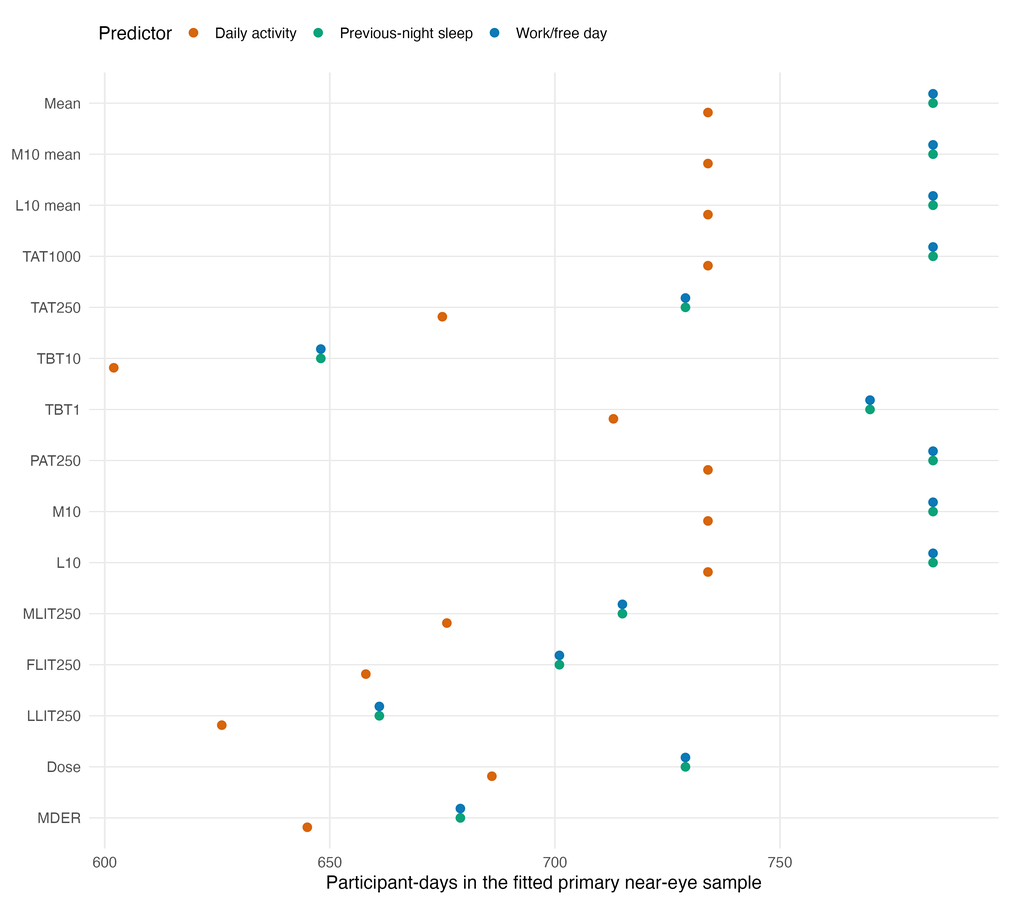

Figure 1: Exact participant-days in each primary near-eye metric-by-predictor fitted sample. Each point is the stored model denominator, not a newly selected sample.

```r
xfun::in_dir(
  file.path(project_root, "audit", "hypotheses", "H06_daily"),
  knitr::include_graphics(file.path(
    project_root,
    "artifacts/10_figures/H06_daily",
    "H06_daily_preparation_primary_sample_support.png"
  ))
)
```

**Show the R code used for this display**

```r
primary_samples |>
  transmute(
    Slot = .data$metric_slot,
    Metric = .data$manuscript_name,
    `Participant-days` = format_range(
      .data$participant_days_min,
      .data$participant_days_max
    ),
    Participants = format_range(
      .data$participants_min,
      .data$participants_max
    ),
    Sites = format_range(.data$sites_min, .data$sites_max),
    `Exact source zeros` = format_range(
      .data$exact_source_zeros_min,
      .data$exact_source_zeros_max
    )
  ) |>
  gt::gt() |>
  gt::cols_hide(columns = "Slot") |>
  compact_gt(font_size = 10.5)
```

Table 5: Exact primary near-eye sample ranges across the three predictor-specific models

| Metric | Participant-days | Participants | Sites | Exact source zeros |
| --- | --- | --- | --- | --- |
| Mean melEDI | 734–784 | 137–141 | 9 | 0 |
| Brightest 10 h mean | 734–784 | 137–141 | 9 | 0 |
| Darkest 10 h mean melEDI | 734–784 | 137–141 | 9 | 92–107 |
| Time above 1,000 lx melEDI | 734–784 | 137–141 | 9 | 85–94 |
| Time above 250 lx melEDI during wake | 675–729 | 136–141 | 9 | 19–25 |
| Time below 10 lx melEDI before sleep | 602–648 | 134–139 | 9 | 10 |
| Time below 1 lx melEDI during sleep | 713–770 | 136–141 | 9 | 4 |
| Longest continuous period above 250 lx melEDI | 734–784 | 137–141 | 9 | 21–26 |
| Midpoint of the brightest 10 hours | 734–784 | 137–141 | 9 | 0 |
| Midpoint of the darkest 10 hours | 734–784 | 137–141 | 9 | 0 |
| Mean timing of exposure above 250 lx melEDI | 676–715 | 137–141 | 9 | 0 |
| First light timing above 250 lx melEDI | 658–701 | 136–140 | 9 | 1 |
| Last light timing above 250 lx melEDI | 626–661 | 137–141 | 9 | 0 |
| melEDI dose | 686–729 | 137–141 | 9 | 0 |
| Melanopic daylight efficacy ratio | 645–679 | 133–136 | 9 | 0 |

Every primary metric-by-predictor sample contains all nine sites. The smallest samples occur where metric admissibility or context linkage is most demanding, not because the fitting function silently removes rows. Complete frames were constructed before fitting and their object identities were sealed.

### Placement and dataset roles

A common sample retains the same participant-days across the models, placements, or dataset constructions being compared. The exploratory jointly adjusted near-eye analysis uses 715 participant-days from 137 participants; other common-sample roles use their exact metric-specific denominators.

**Show the R code used for this display**

```r
sample_roles |>
  transmute(
    Scenario = .data$scenario_label,
    `Metric × predictor cells` = .data$analyzed_metric_predictor_cells,
    Metrics = .data$analyzed_metrics,
    `Participant-days` = format_range(
      .data$participant_days_min,
      .data$participant_days_max
    ),
    Participants = format_range(
      .data$participants_min,
      .data$participants_max
    ),
    Sites = format_range(.data$sites_min, .data$sites_max),
    Role = recode(
      .data$analysis_role,
      primary = "Primary",
      contextual_complement = "Complementary placement",
      paired_complement = "Paired/common placement",
      dataset_sensitivity = "Dataset sensitivity",
      dataset_sensitivity_context = "Complementary dataset sensitivity",
      dataset_paired_complement = "Paired/common dataset sensitivity",
      common_sample_primary = "Primary on common days",
      common_sample_gap = "Gap comparison on common days"
    )
  ) |>
  compact_gt(font_size = 10)
```

Table 6: Exact fitted-sample ranges by placement, dataset, and common-sample role

| Scenario | Metric × predictor cells | Metrics | Participant-days | Participants | Sites | Role |
| --- | --- | --- | --- | --- | --- | --- |
| Primary near eye, all available | 45 | 15 | 602–784 | 133–141 | 9 | Primary |
| Complementary chest, all available | 45 | 15 | 669–870 | 147–154 | 8 | Complementary placement |
| Paired/common near eye | 45 | 15 | 444–614 | 104–112 | 8 | Paired/common placement |
| Paired/common chest | 45 | 15 | 444–614 | 104–112 | 8 | Paired/common placement |
| Gap-timing-unaware near eye, all available | 45 | 15 | 630–777 | 133–141 | 9 | Dataset sensitivity |
| Gap-timing-unaware chest, all available | 45 | 15 | 660–863 | 147–154 | 8 | Complementary dataset sensitivity |
| Gap-timing-unaware paired/common near eye | 42 | 14 | 433–609 | 104–112 | 8 | Paired/common dataset sensitivity |
| Gap-timing-unaware paired/common chest | 42 | 14 | 433–609 | 104–112 | 8 | Paired/common dataset sensitivity |
| Primary near eye, dataset-common | 42 | 14 | 601–777 | 133–141 | 9 | Primary on common days |
| Gap-timing-unaware near eye, dataset-common | 42 | 14 | 601–777 | 133–141 | 9 | Gap comparison on common days |
| Primary chest, dataset-common | 42 | 14 | 660–862 | 147–154 | 8 | Primary on common days |
| Gap-timing-unaware chest, dataset-common | 42 | 14 | 660–862 | 147–154 | 8 | Gap comparison on common days |

Near-eye all-available participant-days define the primary analysis. Chest all-available estimates provide complementary non-ocular placement evidence. Paired/common estimates compare placements on the same days. Dataset-common estimates compare the primary and gap-timing-unaware constructions on identical day keys. Only primary near-eye and gap-timing-unaware near-eye all-available tests enter multiplicity families; the other roles are estimation-only.

### Predictor category and site support

**Show the R code used for this display**

```r
category_support <- predictor_support |>
  filter(.data$support_type == "category") |>
  summarise(
    metric_frames = n_distinct(.data$metric_slot),
    participant_days_min = min(.data$participant_days),
    participant_days_max = max(.data$participant_days),
    .by = c("predictor_order", "reader_name", "category")
  ) |>
  transmute(
    Context = .data$reader_name,
    Category = .data$category,
    `Metric frames` = .data$metric_frames,
    `Participant-days across metrics` = format_range(
      .data$participant_days_min,
      .data$participant_days_max
    )
  )

sleep_support <- predictor_support |>
  filter(.data$support_type == "continuous_range") |>
  summarise(
    metric_frames = n_distinct(.data$metric_slot),
    participant_days_min = min(.data$participant_days),
    participant_days_max = max(.data$participant_days),
    minimum_h = min(.data$previous_sleep_minimum_h),
    median_min_h = min(.data$previous_sleep_median_h),
    median_max_h = max(.data$previous_sleep_median_h),
    maximum_h = max(.data$previous_sleep_maximum_h)
  ) |>
  transmute(
    Context = "Previous-night sleep duration",
    Category = paste0(
      "Observed ", sprintf("%.1f", .data$minimum_h), "–",
      sprintf("%.1f", .data$maximum_h), " h; metric medians ",
      sprintf("%.1f", .data$median_min_h), "–",
      sprintf("%.1f", .data$median_max_h), " h"
    ),
    `Metric frames` = .data$metric_frames,
    `Participant-days across metrics` = format_range(
      .data$participant_days_min,
      .data$participant_days_max
    )
  )

bind_rows(category_support, sleep_support) |>
  compact_gt()
```

Table 7: Primary near-eye predictor support across the 15 metric-specific frames

| Context | Category | Metric frames | Participant-days across metrics |
| --- | --- | --- | --- |
| Work/free day | Free day | 15 | 254–316 |
| Work/free day | Work day | 15 | 387–468 |
| Daily activity status | Active | 15 | 418–510 |
| Daily activity status | Sedentary | 15 | 184–224 |
| Previous-night sleep duration | Observed 0.9–13.9 h; metric medians 7.7–7.8 h | 15 | 648–784 |

**Show the R code used for this display**

```r
site_support |>
  summarise(
    fitted_cells = n(),
    participant_days_min = min(.data$participant_days),
    participant_days_max = max(.data$participant_days),
    .by = c("display_order", "display_name", "color_hex")
  ) |>
  arrange(.data$display_order) |>
  transmute(
    Site = paste0(
      "<span aria-hidden='true' style='color:",
      .data$color_hex,
      ";font-size:1.15em'>●</span> ",
      .data$display_name
    ),
    `Fitted cells` = .data$fitted_cells,
    `Participant-days across cells` = format_range(
      .data$participant_days_min,
      .data$participant_days_max
    )
  ) |>
  gt::gt() |>
  gt::fmt_markdown(columns = "Site") |>
  compact_gt()
```

Table 8: Primary near-eye participant-day support by site across all 45 metric-by-predictor fitted samples

| Site | Fitted cells | Participant-days across cells |
| --- | --- | --- |
| ● Borås (SE) | 45 | 63–76 |
| ● Delft (NL) | 45 | 45–69 |
| ● Dortmund (DE) | 45 | 75–99 |
| ● Tübingen (DE) | 45 | 119–150 |
| ● Munich (DE) | 45 | 52–60 |
| ● Madrid (ES) | 45 | 66–118 |
| ● Izmir (TR) | 45 | 78–100 |
| ● San José (CR) | 45 | 23–31 |
| ● Kumasi (GH) | 45 | 50–81 |

The site table reports observed support, not site-average analytical weighting. Filled dots use consistent study-site colors to identify sites and do not encode significance. Sum-to-zero site coding and site-average marginalization give each included site equal weight in the reported common association even though their observed sample sizes differ.

## Model construction and estimands

### Predictor-specific model hierarchy

For each metric and predictor, the reduced model contains site and the repeated- participant structure. The additive model adds the predictor and estimates the site-average common association, giving each site equal weight. The interaction model adds the complete predictor-by-site block and tests whether the association varies among sites. Work day and Sedentary are the categorical references. All reported intervals are pointwise 95% CIs, not simultaneous intervals.

**Show the R code used for this display**

```r
model_routes |>
  distinct(
    .data$reader_route,
    .data$reduced_formula,
    .data$additive_formula,
    .data$heterogeneity_formula,
    .data$uncertainty
  ) |>
  transmute(
    Route = .data$reader_route,
    Reduced = paste0("`", .data$reduced_formula, "`"),
    Additive = paste0("`", .data$additive_formula, "`"),
    `Predictor-by-site interaction` = paste0("`", .data$heterogeneity_formula, "`"),
    Uncertainty = .data$uncertainty
  ) |>
  gt::gt() |>
  gt::fmt_markdown(columns = c("Reduced", "Additive", "Predictor-by-site interaction")) |>
  compact_gt(font_size = 10)
```

Table 9: Selected model routes and exact formula hierarchy

| Route | Reduced | Additive | Predictor-by-site interaction | Uncertainty |
| --- | --- | --- | --- | --- |
| Fixed-site mixed model with participant random intercept | `response_value ~ site + (1 \| participant_key)` | `response_value ~ site + predictor + (1 \| participant_key)` | `response_value ~ site * predictor + (1 \| participant_key)` | Model-based pointwise 95% CI |
| Two-part occurrence and positive magnitude route; joint slot not estimable | `response_value ~ site + (1 \| participant_key)` | `response_value ~ site + predictor + (1 \| participant_key)` | `response_value ~ site * predictor + (1 \| participant_key)` | Component-specific intervals only; joint association and heterogeneity tests are non-estimable |
| Fixed-site linear model with participant-cluster HC3 covariance | `response_value ~ site` | `response_value ~ site + predictor` | `response_value ~ site * predictor` | Participant-cluster HC3 covariance; participant clusters minus one degrees of freedom; pointwise 95% CI |

The four timing outcomes repaired to participant-cluster HC3 inference are M10 midpoint, L10 midpoint, first timing above 250 lx melEDI, and last timing above 250 lx melEDI. Their fixed-site linear models use participant-cluster HC3 covariance with finite-cluster adjustment and participant-clusters-minus-one degrees of freedom. Other estimable daily outcomes use their selected Gaussian or Tweedie mixed model with a participant random intercept, which allows participants to have different baseline outcome levels.

The exact registered benchmark was retained without silent substitution:

```r
response_value ~ predictor + (predictor | site) +
  (1 | site:participant_key)
```

It is a benchmark because nine sites provide limited support for a random site intercept, random predictor slope, and their correlation. The fixed-site route is the reported estimand. For categorical predictors it is the Free/Work or Active/Sedentary site-average contrast, with every site weighted equally. For previous sleep it is the association per additional hour, also averaged equally over sites. The interaction route reports the complete site-specific association, not an interaction adjustment that must be interpreted alone.

### Multiplicity

**Show the R code used for this display**

```r
multiplicity |>
  mutate(
    Dataset = recode(
      .data$dataset_id,
      primary = "Primary near eye",
      gap_timing_unaware = "Gap-timing-unaware near eye"
    ),
    Test = recode(
      .data$test_type,
      association = "Common association",
      site_heterogeneity = "Predictor-by-site interaction"
    )
  ) |>
  transmute(
    Dataset,
    Predictor = .data$reader_name,
    Test,
    `Named slots` = .data$named_slots,
    Estimable = .data$estimable_slots,
    `Named missing` = .data$named_na_slots,
    `FDR-supported` = .data$fdr_supported_slots,
    `Claim-eligible` = .data$claim_eligible_slots
  ) |>
  gt::gt(groupname_col = "Dataset") |>
  compact_gt(font_size = 10.5)
```

Table 10: Complete primary and gap-timing-unaware false-discovery-rate families

| Predictor | Test | Named slots | Estimable | Named missing | FDR-supported | Claim-eligible |
| --- | --- | --- | --- | --- | --- | --- |
| Gap-timing-unaware near eye |  |  |  |  |  |  |
| Work/free day | Common association | 15 | 14 | 1 | 10 | 10 |
| Daily activity status | Common association | 15 | 14 | 1 | 6 | 6 |
| Previous-night sleep duration | Common association | 15 | 14 | 1 | 13 | 13 |
| Work/free day | Predictor-by-site interaction | 15 | 14 | 1 | 8 | 7 |
| Daily activity status | Predictor-by-site interaction | 15 | 14 | 1 | 3 | 3 |
| Previous-night sleep duration | Predictor-by-site interaction | 15 | 14 | 1 | 1 | 1 |
| Primary near eye |  |  |  |  |  |  |
| Work/free day | Common association | 15 | 14 | 1 | 10 | 10 |
| Daily activity status | Common association | 15 | 14 | 1 | 6 | 6 |
| Previous-night sleep duration | Common association | 15 | 14 | 1 | 12 | 12 |
| Work/free day | Predictor-by-site interaction | 15 | 14 | 1 | 8 | 7 |
| Daily activity status | Predictor-by-site interaction | 15 | 14 | 1 | 2 | 2 |
| Previous-night sleep duration | Predictor-by-site interaction | 15 | 14 | 1 | 1 | 1 |

There are 12 Benjamini–Hochberg FDR families: two datasets × three predictors × two test types. Every family retains all 15 named metric slots. Darkest 10 h mean melEDI remains the named missing slot because its joint test is non-estimable; the family size is not reduced to 14. The frozen MDER raw test occupies slot 15. Only adjusted fields that depend mathematically on the whole family were updated when the remaining slots became available.

## Model checks, influence, and sensitivities

### Three-class model-check architecture

Hard failure was reserved for an unavailable or non-estimable base result, convergence or Hessian failure, singularity, rank or covariance failure, invalid timing support, observed-response support failure, or visually confirmed gross residual behavior. Residual distribution was judged visually from residual-versus-fitted and Q–Q displays for Gaussian or HC3 fits. Tweedie fits used Pearson residual-versus-fitted displays and zero-mass and prediction- support checks; normal Pearson residuals were not required.

All 468 non-L10 metric-by-predictor-by-scenario cells had complete visual review and no gross visual or hard construct failure after the gap clock-unit repair. Each was retained as acceptable with limitations. Autocorrelation, participant or site deletion, exact-period, and response-family checks are mandatory row-linked sidecars. They qualify interpretation but do not by themselves fail an otherwise estimable result.

**Show the R code used for this display**

```r
diagnostics |>
  transmute(
    Domain = .data$domain,
    Classification = .data$reader_classification,
    Cells = .data$cells,
    Role = if_else(
      .data$hard_gate_input,
      "Overall classification input",
      "Nonblocking limitation sidecar"
    )
  ) |>
  gt::gt(groupname_col = "Domain") |>
  gt::fmt_integer(columns = "Cells") |>
  compact_gt(font_size = 10)
```

Table 11: Stored model-check classifications and mandatory limitation sidecars

| Classification | Cells | Role |
| --- | --- | --- |
| Overall H01-aligned cell status |  |  |
| Acceptable with limitations | 468 | Overall classification input |
| Visual residual review |  |  |
| Review limitation | 468 | Overall classification input |
| Participant/site deletion influence |  |  |
| Stable | 270 | Nonblocking limitation sidecar |
| Substantial limitation | 128 | Nonblocking limitation sidecar |
| Non-estimable deletion refit | 24 | Nonblocking limitation sidecar |
| Unstable | 46 | Nonblocking limitation sidecar |
| Gaussian Student-t sensitivity |  |  |
| Non-estimable sensitivity | 7 | Nonblocking limitation sidecar |
| Stable | 20 | Nonblocking limitation sidecar |
| Substantial limitation | 2 | Nonblocking limitation sidecar |
| Timing Student-t sensitivity |  |  |
| Stable | 135 | Nonblocking limitation sidecar |
| Substantial limitation | 8 | Nonblocking limitation sidecar |
| Unstable | 1 | Nonblocking limitation sidecar |
| Mixed-model actual-date AR sidecar |  |  |
| Acceptable | 3 | Nonblocking limitation sidecar |
| Acceptable pre-sleep no-nugget sensitivity | 1 | Nonblocking limitation sidecar |
| Not triggered | 119 | Nonblocking limitation sidecar |
| Triggered; no counterpart for the non-Gaussian route | 63 | Nonblocking limitation sidecar |
| Unresolved numerical failure | 13 | Nonblocking limitation sidecar |
| Unresolved singular fit | 104 | Nonblocking limitation sidecar |
| Residual dependence remained | 21 | Nonblocking limitation sidecar |
| Timing HC3 actual-date AR sidecar |  |  |
| Stable | 95 | Nonblocking limitation sidecar |
| Substantial limitation | 7 | Nonblocking limitation sidecar |
| Unresolved numerical failure | 32 | Nonblocking limitation sidecar |
| Unstable | 10 | Nonblocking limitation sidecar |
| Exact-period sensitivity |  |  |
| Stable | 12 | Nonblocking limitation sidecar |
| Substantial limitation | 6 | Nonblocking limitation sidecar |

The sidecars make limitations visible rather than erasing an estimable association. Examples include Student-t shifts, unresolved or singular AR counterparts, residual dependence that remained after an AR fit, direction changes under participant or site deletion, and exact-period sensitivity. They are reported with the corresponding result and constrain generalization, especially where site-interaction estimates are sensitivity-dependent.

### Prespecified and complementary branches

**Show the R code used for this display**

```r
sensitivity_registry |>
  transmute(
    Branch = .data$branch,
    `Stored scope` = .data$stored_scope,
    Question = .data$scientific_question,
    Role = .data$inferential_role
  ) |>
  compact_gt(font_size = 10.5)
```

Table 12: Stored sensitivity and complementary-analysis branches

| Branch | Stored scope | Question | Role |
| --- | --- | --- | --- |
| Chest placement | All-available chest participant-days | Whether complementary non-ocular placement evidence is directionally compatible | Estimation only |
| Paired/common placement | Near-eye and chest estimates on the same participant-days | Whether placement comparisons are driven by unequal day samples | Complementary estimation |
| Gap-timing-unaware dataset | The 50%-per-hour and 80%-per-day coverage rules remain, but remaining gap timing does not trigger the additional metric-specific adjustment | Whether the primary conclusion depends on using the timing of remaining gaps | Separate near-eye 15-slot FDR families |
| Dataset-common sample | Primary and gap-timing-unaware estimates on identical day keys | Whether different retained days explain a dataset comparison | Estimation only |
| Response-family checks | Gaussian Student-t or Tweedie alternatives where prespecified and estimable | Whether distributional assumptions materially move an association | Mandatory limitation sidecar |
| Actual-date AR(1) | Consecutive observed dates within participant; gaps start new sequences | Whether residual day-to-day dependence materially moves an association | Mandatory nonblocking sidecar |
| Exact-period check | Exactly identified longest continuous-period records | Whether interval uncertainty changes the longest-period association | Mandatory nonblocking sidecar |
| Participant and site deletion | Checkpointed one-cluster-at-a-time refits | Whether one participant or one site dominates an association | Mandatory nonblocking sidecar |
| Registered random-site benchmark | Signed predictor random slope by site with participant nested in site | Whether the exact registered structure is estimable without replacing it | Benchmark only |

These branches answer distinct questions. The chest analysis is not an ocular exposure estimate. Paired/common placement analyses are not direct sensor- position effects. The gap-timing-unaware dataset is a preparation sensitivity, and its own complete 15-slot near-eye families prevent a sensitivity result from being folded into the primary family after inspection.

## Exploratory jointly adjusted daily models

For mixed-model outcomes, the interaction specification is:

```r
response_value ~
  site * work_free_day +
  site * activity_status +
  site * previous_sleep_duration_centered_h +
  (1 | participant_key)
```

The repaired timing outcomes use the corresponding fixed-site linear model without the participant random intercept and use participant-cluster HC3 covariance. Thus, each context is adjusted for the other two, while each predictor may still vary by site. The six exploratory 15-slot families are kept separate from the predictor-specific primary families.

**Show the R code used for this display**

```r
joint_registry |>
  transmute(
    Slot = .data$metric_slot,
    Metric = .data$manuscript_name,
    Family = paste(.data$response_family, .data$response_transform, sep = "; "),
    Route = recode(
      .data$route,
      mixed_model = "Mixed model",
      participant_cluster_HC3 = "Participant-cluster HC3"
    ),
    `Participant-days` = .data$participant_days,
    Participants = .data$participants,
    Sites = .data$sites
  ) |>
  gt::gt() |>
  gt::cols_hide(columns = "Slot") |>
  gt::fmt_integer(columns = c("Participant-days", "Participants", "Sites")) |>
  compact_gt(font_size = 10.5)
```

Table 13: Common-frame support and route for the exploratory jointly adjusted daily analysis

| Metric | Family | Route | Participant-days | Participants | Sites |
| --- | --- | --- | --- | --- | --- |
| Mean melEDI | gaussian; log10_offset_0.1 | mixed_model_participant_random_intercept | 715 | 137 | 9 |
| Brightest 10 h mean | gaussian; log10_offset_0.1 | mixed_model_participant_random_intercept | 715 | 137 | 9 |
| Time above 1,000 lx melEDI | tweedie_log; identity | mixed_model_participant_random_intercept | 715 | 137 | 9 |
| Time above 250 lx melEDI during wake | tweedie_log; identity | mixed_model_participant_random_intercept | 669 | 136 | 9 |
| Time below 10 lx melEDI before sleep | gaussian; identity | mixed_model_participant_random_intercept | 597 | 134 | 9 |
| Time below 1 lx melEDI during sleep | tweedie_log; identity | mixed_model_participant_random_intercept | 707 | 136 | 9 |
| Longest continuous period above 250 lx melEDI | gaussian; log10_offset_0.1 | mixed_model_participant_random_intercept | 715 | 137 | 9 |
| Midpoint of the brightest 10 hours | gaussian; clock_hours | fixed_site_lm_participant_cluster_HC3 | 715 | 137 | 9 |
| Midpoint of the darkest 10 hours | gaussian; clock_hours_midnight_after_16 | fixed_site_lm_participant_cluster_HC3 | 715 | 137 | 9 |
| Mean timing of exposure above 250 lx melEDI | gaussian; clock_hours | mixed_model_participant_random_intercept | 658 | 137 | 9 |
| First light timing above 250 lx melEDI | gaussian; clock_hours | fixed_site_lm_participant_cluster_HC3 | 641 | 136 | 9 |
| Last light timing above 250 lx melEDI | gaussian; clock_hours | fixed_site_lm_participant_cluster_HC3 | 609 | 137 | 9 |
| melEDI dose | gaussian; log10_offset_0.1 | mixed_model_participant_random_intercept | 667 | 137 | 9 |
| Melanopic daylight efficacy ratio | gaussian; identity | mixed_model_participant_random_intercept | 631 | 131 | 9 |

## Exploratory 30-minute clock-time GAMM

The clock-time analysis has a different row and estimand. Its outcome $Y$ is the arithmetic mean melEDI in an admissible 30-minute bin. The model response is $Z = \log_{10}(Y + 0.1\ \mathrm{lx})$. Exact zeros remain in this one-part Gaussian model. The displayed inverse transform, $10^\eta - 0.1$, is a back-transform of the conditional mean log response. It is geometric-mean-like for $Y+0.1$ and is not raw-scale arithmetic $E[Y]$.

**Show the R code used for this display**

```r
temporal_formula |>
  transmute(
    Response = paste(.data$response_source, .data$response_transform, sep = "; "),
    Family = paste(.data$family, .data$link, sep = "; "),
    Formula = paste0("`", .data$formula, "`"),
    Estimand = .data$estimand,
    `Inverse-transform qualification` = .data$inverse_transform_qualification
  ) |>
  gt::gt() |>
  gt::fmt_markdown(columns = "Formula") |>
  compact_gt(font_size = 10)
```

Table 14: Exact exploratory 30-minute response, model, and estimand

| Response | Family | Formula | Estimand | Inverse-transform qualification |
| --- | --- | --- | --- | --- |
| arithmetic_mean_medi_lx; log10(melEDI + 0.1 lx) | Gaussian; identity | `response ~ s(time_hour, bs = "cc", k = 12) + s(time_hour, work_free_day, bs = "sz", k = 12) + s(time_hour, activity_status, bs = "sz", k = 12) + s(time_hour, by = sleep_between_h, k = 12) + s(time_ho… | E[log10(30-minute arithmetic-mean melEDI + 0.1 lx) \| local time, work/free day, daily activity status, within- and between-person previous-night sleep duration, site, participant, participant-day] | back-transform of a mean log response; geometric-mean-like and conditional-median scale, not raw-scale E[Y] |

The model was fitted with `mgcv::bam()`, fREML, `discrete = TRUE`, one R thread, and global 0/24 knots. The global clock smooth is cyclic cubic with $k=12$. Work/free day, activity, and site use sum-to-zero factor smooths with $k=12$ and the default thin-plate time marginal, not a cyclic marginal. Participant uses a factor smooth with $k=10$, and participant-day uses a random intercept smooth. Previous sleep is separated into between-participant and within-participant smooth functions.

Rows are ordered by site, participant, local date, true source time, and clock bin. A working AR(1) sequence restarts at each participant-day and at every missing, non-one-to-one, or physically discontinuous true-time boundary. Each frame’s rho was estimated anew from its own preliminary full-model response residuals and then fixed for the final fit.

**Show the R code used for this display**

```r
temporal_support |>
  transmute(
    Dataset = .data$data_scenario_label,
    Placement = .data$placement_label,
    Sample = recode(
      .data$sample_scenario,
      all_available = "All available",
      paired_common = "Paired/common"
    ),
    `30-minute bins` = .data$observations_30_minute,
    `Participant-days` = .data$participant_days,
    Participants = .data$participants,
    Sites = .data$sites,
    `Exact zero bins` = .data$exact_zero_bins,
    `AR sequences` = .data$ar_sequences,
    Rho = .data$rho
  ) |>
  gt::gt(groupname_col = "Dataset") |>
  gt::fmt_integer(columns = c(
    "30-minute bins", "Participant-days", "Participants", "Sites",
    "Exact zero bins", "AR sequences"
  )) |>
  gt::fmt_number(columns = "Rho", decimals = 3) |>
  compact_gt(font_size = 10.5)
```

Table 15: Exact fitted support and working AR(1) parameter for the exploratory clock-time models

| Placement | Sample | 30-minute bins | Participant-days | Participants | Sites | Exact zero bins | AR sequences | Rho |
| --- | --- | --- | --- | --- | --- | --- | --- | --- |
| Primary dataset |  |  |  |  |  |  |  |  |
| Near eye | All available | 33,057 | 715 | 137 | 9 | 10,225 | 1,217 | 0.579 |
| Chest | All available | 36,558 | 789 | 149 | 8 | 11,703 | 1,345 | 0.570 |
| Near eye | Paired/common | 25,583 | 553 | 109 | 8 | 8,114 | 947 | 0.579 |
| Chest | Paired/common | 25,583 | 553 | 109 | 8 | 8,321 | 947 | 0.561 |
| Gap-timing-unaware dataset |  |  |  |  |  |  |  |  |
| Near eye | All available | 32,969 | 710 | 137 | 9 | 10,172 | 1,053 | 0.576 |
| Chest | All available | 36,404 | 782 | 149 | 8 | 11,631 | 1,138 | 0.564 |

Whole-function tests and 95% intervals for clock-specific associations are reported on the transformed scale. Every displayed interval is pointwise; no simultaneous confidence band was constructed. The temporal analysis is exploratory and does not replace a daily-metric slot or the selected hourly H06 analysis.

## Code, stored outputs, and reproducibility

### Execution order

**Show the R code used for this display**

```r
code_map |>
  transmute(
    Order = .data$sequence,
    Module = paste0("`", .data$module, "`"),
    Responsibility = .data$responsibility,
    `SHA-256 prefix` = substr(.data$sha256, 1L, 12L)
  ) |>
  gt::gt() |>
  gt::fmt_markdown(columns = "Module") |>
  compact_gt(font_size = 10)
```

Table 16: H06 daily-metric modules in analytical order

| Order | Module | Responsibility | SHA-256 prefix |
| --- | --- | --- | --- |
| 1 | `scripts/hypotheses/H06_daily/h06_daily_contract.R` | Daily metric, predictor, formula, reference-coding, and temporal contracts | 469b3a01c92c |
| 2 | `scripts/hypotheses/H06_daily/h06_daily_data.R` | Participant-day frame assembly from prepared metrics and context records | 92e6400039d9 |
| 3 | `scripts/hypotheses/H06_daily/h06_daily_non_l10_production_contract.R` | Non-L10 run, sample, route, and multiplicity contracts | 95fe89ca4d3c |
| 4 | `scripts/hypotheses/H06_daily/h06_daily_non_l10_production_modeling.R` | Mixed-model and HC3 routes, contrasts, diagnostics, and sidecars | e06e1d129505 |
| 5 | `scripts/hypotheses/H06_daily/run_h06_daily_non_l10_production_base.R` | Checkpointed non-L10 model execution | 78c435a36426 |
| 6 | `scripts/hypotheses/H06_daily/run_h06_daily_non_l10_production_sensitivities.R` | Response-family and actual-date dependence sensitivities | a6508fb65f1a |
| 7 | `scripts/hypotheses/H06_daily/run_h06_daily_non_l10_production_influence.R` | Participant and site deletion checks | 637c8fa08fe5 |
| 8 | `scripts/hypotheses/H06_daily/h06_daily_l10_metric011_contract.R` | Exact-zero occurrence and strictly positive L10 magnitude contract | dc21b6199d42 |
| 9 | `scripts/hypotheses/H06_daily/run_h06_daily_l10_metric011_production.R` | Two-part L10 branch retained as non-estimable for joint inference | 6847b70c1a56 |
| 10 | `scripts/hypotheses/H06_daily/h06_daily_mder_metric010_contract.R` | Mean-of-viable-one-minute-ratios MDER contract | 373faa442d3f |
| 11 | `scripts/hypotheses/H06_daily/run_h06_daily_mder_metric010_production.R` | MDER model and sensitivity execution | deac80566ac9 |
| 12 | `scripts/hypotheses/H06_daily/finalize_h06_daily_gap_clock_repair.R` | Task-local conversion of gap timing values to clock hours and resealing | 8ea2c2805c3c |
| 13 | `scripts/hypotheses/H06_daily/run_h06_daily_joint_context_exploratory.R` | Exploratory jointly adjusted day type, activity, and sleep models | a1f7596a28da |
| 14 | `scripts/hypotheses/H06_daily/build_h06_daily_temporal_h02_production_frames.R` | Supported 30-minute frames and true-time AR sequence boundaries | 875bfc4e0baa |
| 15 | `scripts/hypotheses/H06_daily/run_h06_daily_temporal_h02_production_models.R` | H02-aligned exploratory BAM fits with frame-specific working AR(1) | d18657c5d902 |
| 16 | `scripts/hypotheses/H06_daily/extract_h06_daily_temporal_h02_production.R` | Pointwise clock-time functions and whole-function tests from stored fits | 512c9a98774f |
| 17 | `scripts/hypotheses/H06_daily/build_h06_daily_stage3_reader.R` | Reader-facing tables, figures, and paired source data | 0ad86f6d36f5 |
| 18 | `notebooks/hypotheses/H06_daily.qmd` | Complementary results report | 0318fd6cf874 |
| 19 | `scripts/hypotheses/H06_daily/build_h06_daily_preparation_artifacts.R` | Bounded descriptive and provenance source data for this companion | 3196d183e35b |
| 20 | `audit/hypotheses/H06_daily/H06_daily_analysis_preparation.qmd` | Preparation and provenance display from stored scientific artifacts | fdfe94cf96e1 |

Contracts and frame construction are separated from fitting, model checking, influence analysis, reader displays, and this provenance page. This separation allows a stored result to be traced to the exact frame and script without requiring the report renderer to execute scientific modeling code.

### Stored output trace

**Show the R code used for this display**

```r
output_trace |>
  transmute(
    Output = .data$role,
    Path = paste0("`", .data$relative_path, "`"),
    Type = .data$object_type,
    `SHA-256 prefix` = substr(.data$sha256, 1L, 12L),
    Bytes = .data$bytes
  ) |>
  gt::gt() |>
  gt::fmt_markdown(columns = "Path") |>
  gt::fmt_integer(columns = "Bytes") |>
  compact_gt(font_size = 10)
```

Table 17: Principal stored outputs used by the results report and this provenance companion

| Output | Path | Type | SHA-256 prefix | Bytes |
| --- | --- | --- | --- | --- |
| Primary and gap daily-grid results | `artifacts/09_tables/H06_daily/H06_daily_gap_clock_repair_primary_gap_results.csv` | file | bd0ca07855af | 18,701 |
| Twelve complete 15-slot BH families | `artifacts/09_tables/H06_daily/H06_daily_gap_clock_repair_bh_families.csv` | file | 773e299346cb | 255,089 |
| Final H01-aligned cell classifications | `artifacts/08_diagnostics/H06_daily/H06_daily_gap_clock_repair_h01_classification.csv` | file | e7aa89e35d78 | 1,437,318 |
| Participant and site deletion summary | `artifacts/08_diagnostics/H06_daily/H06_daily_gap_clock_repair_influence_summary.csv` | file | 6b2a0f4c831e | 76,459 |
| L10 two-part model bundle | `artifacts/07_models/H06_daily/H06_daily_l10_metric011_production_models.rds` | file | 8dede8ff6e50 | 4,182,296 |
| L10 component and joint-test record | `artifacts/09_tables/H06_daily/H06_daily_l10_metric011_model_tests.csv` | file | 6fa551b25802 | 13,244 |
| MDER model bundle | `artifacts/07_models/H06_daily/H06_daily_mder_metric010_production_models.rds` | file | 0d81cff7c5b6 | 19,533,491 |
| MDER model-test record | `artifacts/09_tables/H06_daily/H06_daily_mder_metric010_model_tests.csv` | file | 6d0ac3feba8e | 3,607 |
| Exploratory joint-context per-cell model directory | `artifacts/07_models/H06_daily/H06_daily_joint_context_exploratory_cells` | directory | b06d0b4aeb49 | 12,699,954 |
| Exploratory jointly adjusted tests | `artifacts/09_tables/H06_daily/H06_daily_joint_context_exploratory_tests.csv` | file | 5f322ca0c438 | 30,716 |
| Temporal GAMM fitted support | `artifacts/08_diagnostics/H06_daily/H06_daily_temporal_h02_production_support_overall.csv` | file | f24ff12fce1a | 1,614 |
| Temporal GAMM whole-function tests | `artifacts/09_tables/H06_daily/H06_daily_temporal_h02_production_whole_function_tests.csv` | file | c953f6b4074f | 9,022 |
| Primary reader source data | `artifacts/11_source_data/H06_daily/H06_daily_stage3_primary_results.csv` | file | c81af8827137 | 42,211 |
| Placement reader source data | `artifacts/11_source_data/H06_daily/H06_daily_stage3_placement_results.csv` | file | 55fc295f3d5a | 112,128 |
| Gap-timing-unaware reader source data | `artifacts/11_source_data/H06_daily/H06_daily_stage3_gap_results.csv` | file | d6cce7a92bb3 | 44,105 |
| Results source | `notebooks/hypotheses/H06_daily.qmd` | file | 0318fd6cf874 | 61,938 |
| Results HTML | `notebooks/hypotheses/H06_daily.html` | file | 5a20c0680011 | 3,617,976 |

Every durable reader figure has paired source data and alt text. The daily-grid figures use original response units in labels. Reader-facing displays of zero-containing, strongly right-skewed melEDI use the predefined symmetric-log (symlog) display. It retains zero, is linear near zero, and uses base 10 with a 1 lx threshold, while the stored source values remain untransformed. P-values are stored numerically, displayed to three decimals with values below 0.001 shown as `<0.001`, and emphasized only under their explicitly labelled raw or adjusted decision rule.

The synchronized environment uses R 4.6.1. Input and output manifests record relative paths, SHA-256 identities, byte sizes, producing scripts, and consequential package versions. The complete fitted-sample registry and the figure source data are available as CSV files beside the model, model-check, table, and figure artifacts.